# Carbon challenge calculations

Matt Russell

4/27/2020

The following is a document to perform calculations for the University of Minnesota Extension’s Tree and Woodland Carbon Capture Challenge. The general approach is to (1) input tree and woodland diameter measurements (2) calculate the aboveground biomass of each tree, and (3) calculate the carbon content in the tree or woodland.

```r
library(tidyverse)
library(googlesheets4)
library(knitr)
library(formattable)
library(kableExtra)
```

Here’s some test data explained in the [Google Doc instructions](https://docs.google.com/document/d/1-4J-NvyEF7Y-0F6aeuXYBtGkY5y8Cu7sZ0k9lvjON4o/edit#heading=h.n8brrdl98b58).

Example for a single tree:

```r
tree <- tribble(
  ~SPGRP_JENKINS, ~TIME, ~DIA,
  "Maple/oak/hickory/beech", "BEFORE", 10.5,
  "Maple/oak/hickory/beech", "AFTER", 11.2

)
```

The Jenkins et al. 2003 paper describes a set of species-specific equations to estimate aboveground biomass in trees. The calculation relies on species and diameter at breast height (inches) and calculates biomass in pounds: http://www.fs.fed.us/ne/durham/4104/papers/Heathbiomass_eqns.pdf

```r
# Here is the function:

total_AGB<-function(SPGRP_JENKINS,DIA){
if(SPGRP_JENKINS=='Aspen')
  {JENKINS_TOTAL_B1=-2.2094; JENKINS_TOTAL_B2=2.3867}
if(SPGRP_JENKINS=='Cedar/larch')
  {JENKINS_TOTAL_B1=-2.0336; JENKINS_TOTAL_B2=2.2592}
if(SPGRP_JENKINS=='Maple/oak/hickory/beech')
  {JENKINS_TOTAL_B1=-2.0127; JENKINS_TOTAL_B2=2.4342}
if(SPGRP_JENKINS=='Mixed hardwood')
  {JENKINS_TOTAL_B1=-2.48; JENKINS_TOTAL_B2=2.4835}
if(SPGRP_JENKINS=='Pine')
  {JENKINS_TOTAL_B1=-2.5356; JENKINS_TOTAL_B2=2.4349}
if(SPGRP_JENKINS=='Soft maple/birch')
  {JENKINS_TOTAL_B1=-1.9123; JENKINS_TOTAL_B2=2.3651}
if(SPGRP_JENKINS=='Spruce')
  {JENKINS_TOTAL_B1=-2.0773; JENKINS_TOTAL_B2=2.3323}
if(SPGRP_JENKINS=='True fir/hemlock')
  {JENKINS_TOTAL_B1=-2.5384; JENKINS_TOTAL_B2=2.4814}
  # Calculate total aboveground biomass of each tree (AGB)
  # Note the equation predicts biomass in kg, but we  convert it into pounds
  AGB=(exp(JENKINS_TOTAL_B1+JENKINS_TOTAL_B2*log(DIA*2.54)))*2.20462
    return(AGB=AGB)}
```

Now, we can apply the function total_AGB to estimate total aboveground biomass and add it as a column in our tree dataset. Then, we’ll calculate the carbon content, assuming half of biomass is carbon:

```r
tree$AGB<-mapply(total_AGB,SPGRP_JENKINS=tree$SPGRP_JENKINS,DIA=tree$DIA)
tree$C<-tree$AGB*0.5

# Calculate CO2 equivalents
tree$CO2e <- tree$C * 3.667

tree
```

```
## # A tibble: 2 x 6
##   SPGRP_JENKINS           TIME     DIA   AGB     C  CO2e
##   <chr>                   <chr>  <dbl> <dbl> <dbl> <dbl>
## 1 Maple/oak/hickory/beech BEFORE  10.5  872.  436. 1599.
## 2 Maple/oak/hickory/beech AFTER   11.2 1020.  510. 1871.
```

## Load the pre-growing season measurements of the Carbon Capture Challenge

[output not shown]

```
## The googlesheets4 package is using a cached token for matt@arbor-analytics.com.
```

```
## Reading from "Carbon Challenge Single Tree Clean"
```

```
## Range "Form Responses 1"
```

Tree entries in the MN Carbon Capture Challenge (Single tree category).

| Team | County | Spp2 | DBH | C |
| --- | --- | --- | --- | --- |
| Gustafson’s Carbon Farm | Wright | Mixed hardwood | 23.5 | 2375.2 |
| Eat Outside the Box | Ottertail | Mixed hardwood | 17 | 1062.9 |
| TheBeesHive | Ramsey | Maple/oak/hickory/beech | 29 | 5169.1 |
| Paradise Lost Plantation | Hubbard | Pine | 23.2 | 1785.1 |
| Gupta Gang | Olmsted | Maple/oak/hickory/beech | 13.9" | 862.9 |
| Girth Getters | Ramsey | Maple/oak/hickory/beech | 25" and 11/16ths | 3847.6 |
| Cul-de-sac Carbon Eaters | Dakota | Mixed hardwood | 19.9 | 1571.7 |
| Phenoguy | Itasca | Maple/oak/hickory/beech | 16.6 | 1991.8 |
| Drimels Brush up on Hardwoods (DBH) | Washington | Maple/oak/hickory/beech | 33.1 | 7132.0 |
| Team Trillium | Hubbard | Pine | 28 | 2821.8 |
| Webster Tree Frogs | Rice | Maple/oak/hickory/beech | 15.1 | 1055.6 |
| Webster Tree Frogs | Rice | Maple/oak/hickory/beech | 11.92 | 593.6 |
| Silverlicious | Ramsey | Maple/oak/hickory/beech | 10.35 | 420.9 |
| Green Air | Ramsey | Maple/oak/hickory/beech | 58.6" | 28645.9 |
| Rex’s Team | Hennepin | Maple/oak/hickory/beech | 34.4 inches | 7833.1 |
| Duluth Lakeside | St. Louis | Aspen | 10.54 inches | 309.2 |
| Strauss Haus | Olmsted | Pine | 2.866" (9" circumference) | 11.0 |
| Tree Guyz | Saint Louis | Spruce | 10 3/8" | 284.4 |
| Roseville SilverMaples | Ramsey | Maple/oak/hickory/beech | 46 | 15890.2 |
| Izzy’s Inches | Steele | Aspen | 46 | 10411.0 |
| Henry’s Tree | Steele | Mixed hardwood | 2.8 | 12.1 |
| Ozzy | Crow Wing | Maple/oak/hickory/beech | 36.5 | 9048.5 |
| Wabedo Woods | Cass | Maple/oak/hickory/beech | 14.49 | 954.8 |
| Team Tamarak | Hennepin | Cedar/larch | 7.2 | 102.5 |
| Tree Detective Denise | Becker | Maple/oak/hickory/beech | 57 inches | 26779.1 |

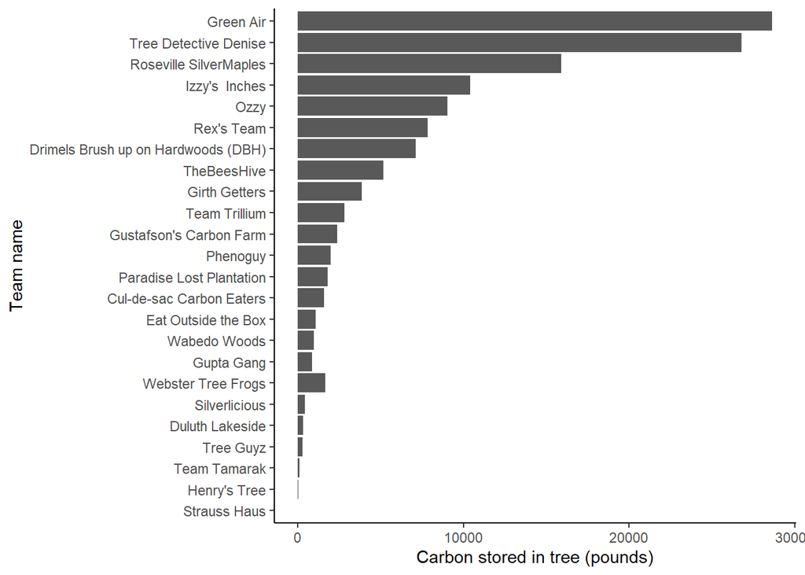

Here is some example data from a woodland:

```r
wood <- tribble(
  ~SPGRP_JENKINS, ~TIME, ~DIA,
  "Maple/oak/hickory/beech", "BEFORE", 6.7,
  "Maple/oak/hickory/beech", "BEFORE", 7.7,
  "Pine", "BEFORE", 8.9,
  "Maple/oak/hickory/beech", "BEFORE", 5.9,
  "Maple/oak/hickory/beech", "BEFORE", 8.9,
  "Pine", "BEFORE", 10.3,
  "Pine", "BEFORE", 11.5,
  "Maple/oak/hickory/beech", "BEFORE", 8.8,
  "Maple/oak/hickory/beech", "AFTER", 7.0,
  "Maple/oak/hickory/beech", "AFTER", 7.8,
  "Pine", "AFTER", 9.5,
  "Maple/oak/hickory/beech", "AFTER", 6.2,
  "Maple/oak/hickory/beech", "AFTER", 9.4,
  "Pine", "AFTER", 10.3,
  "Pine", "AFTER", 11.7,
  "Maple/oak/hickory/beech", "AFTER", 8.9
)
```

Remember, participants are measuring 1/10th acre plots. We’ll expand to this value in the calculation.

```r
PLOT_SIZE = 10

wood$AGB<-mapply(total_AGB,SPGRP_JENKINS=wood$SPGRP_JENKINS,DIA=wood$DIA)
wood$C<-wood$AGB*0.5

wood$C_sum<-wood$C*PLOT_SIZE

wood_grouped <- group_by(wood, TIME)

plot.C <- summarize(wood_grouped,
  CPA = sum(C_sum))
plot.C$CO2e <- plot.C$CPA * 3.667
plot.C
```

```
## # A tibble: 2 x 3
##   TIME      CPA   CO2e
##   <chr>   <dbl>  <dbl>
## 1 AFTER  19066. 69915.
## 2 BEFORE 17768. 65156.
```